# STAT 385 - Homework 6

### Boxplot

- There are 3 parts to this exercise: each part worths 5 points.
- **(a)** Graph a boxplot of `carat` vs `cut`.
  - `carat` as the $y$-axis and `cut` as the $x$-axis.

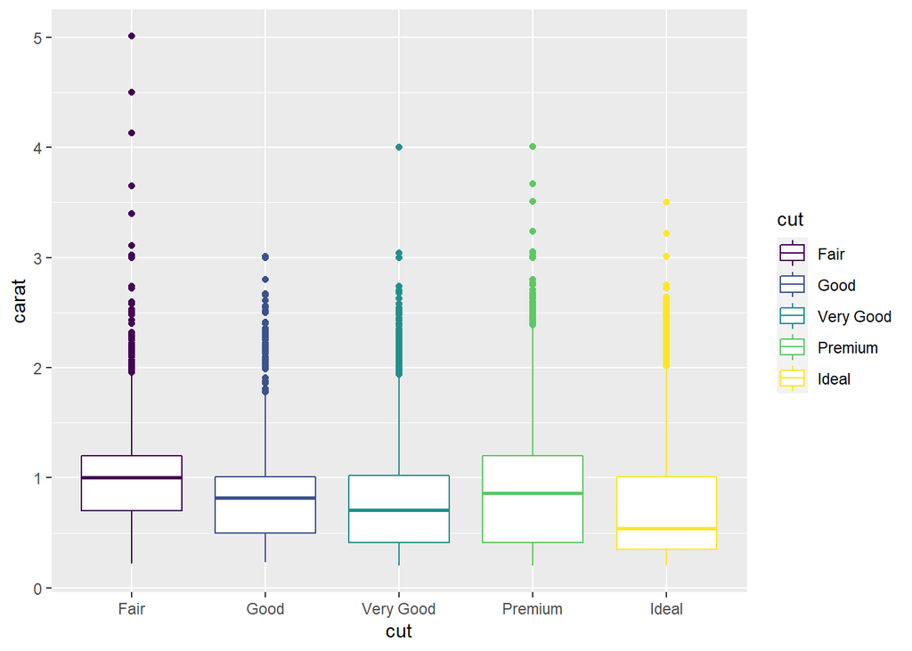

```r
# add your graph here
sp <- ggplot(data = diamonds) +
  geom_boxplot(mapping = aes(x = cut, y = carat, color = cut))
sp
```

- **(b) With the plot above**, rotate it so `cut` is on the $y$-axis and `carat` is on the $x$-axis.
  - Make sure the plot is still a boxplot.

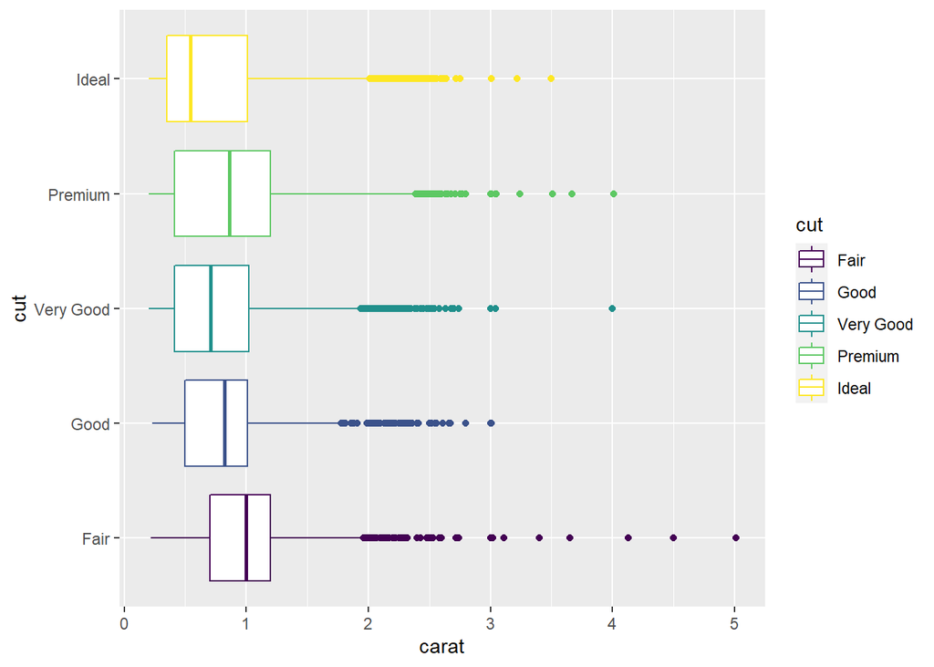

```r
# add your graph here
sp + coord_flip()
```

- **(c) With the plot from (b)**, color the boxplot dark blue.

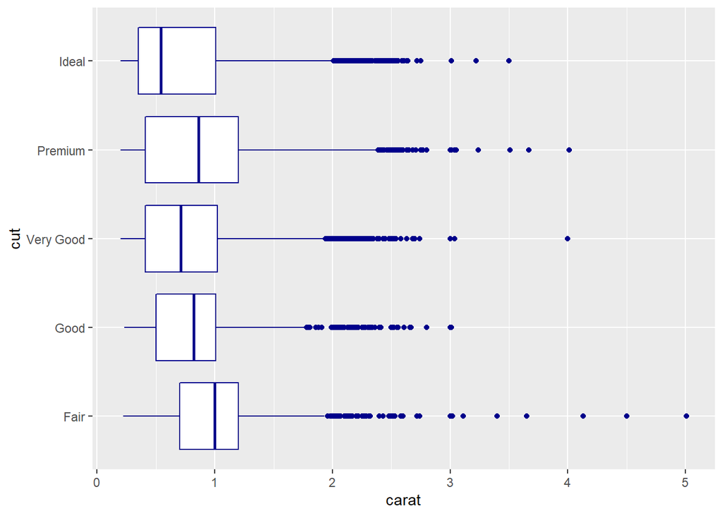

```r
# add your graph here
sp2 <- ggplot(data = diamonds) +
  geom_boxplot(mapping = aes(x = cut, y = carat), color = "dark blue")
sp2 + coord_flip()
```

### Histogram

- There are 3 parts to this exercise: each part worths 5 points.
- **(a)** Graph a histogram of `price`.

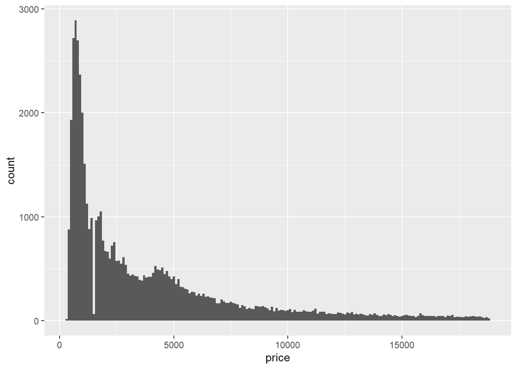

```r
# add your graph here
ggplot(data = diamonds, aes(x=price)) +
  geom_histogram(binwidth=100)
```

- **(b) With the plot above**, color the bars dark orange.

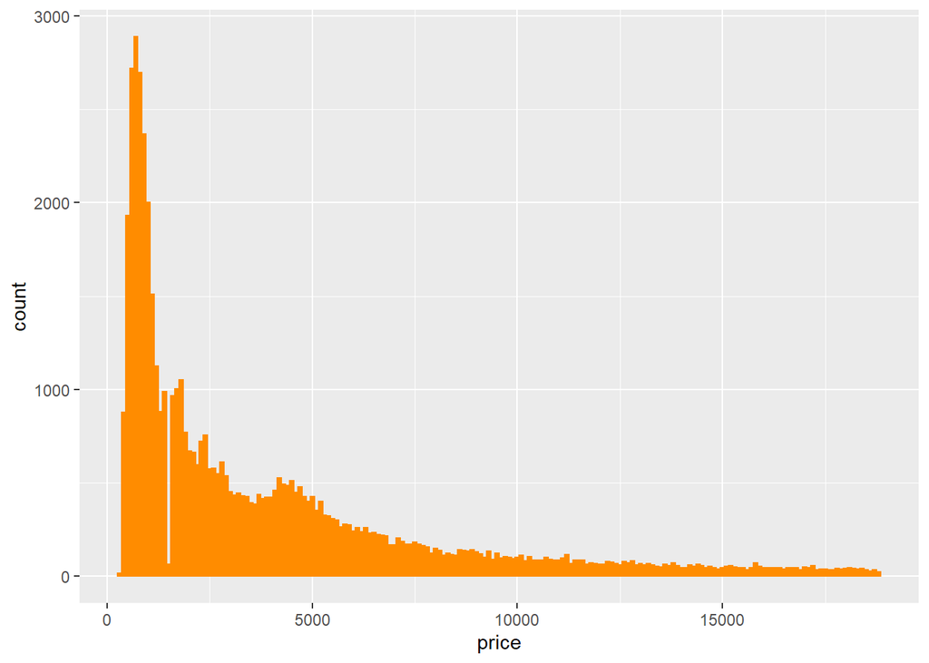

```r
# add your graph here
bp <- ggplot(data = diamonds, aes(x=price)) +
  geom_histogram(binwidth=100, color = "dark orange", fill = "dark orange")
bp
```

- **(c) With the plot from (b)**, change the number of bins to 50.

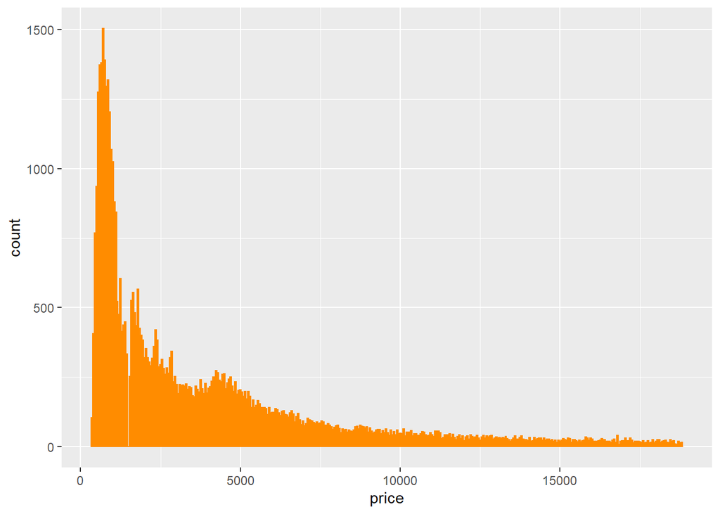

```r
# add your graph here
ggplot(data = diamonds, aes(x=price)) +
  geom_histogram(binwidth=50, color = "dark orange", fill = "dark orange")
```

## Dataset: 2015 Flight Delays and Cancellations Data

In this exercise, we continue to work with the 2015 Flight Delays and Cancellations Data provided by the U.S. Department of Transportation. This is a huge dataset availalbe on [Kaggle](https://www.kaggle.com/usdot/flight-delays#airports.csv). But for us, we will only take a look at flights **flying out** from O’Hare International Airport (ORD) in January, 2015.

### Load data

- I have filtered out the data specific to O’Hare and stored it in `ohare_jan.csv`. This filtered data is available at the URL: https://nkha149.github.io/stat385-sp2020/files/data/ohare_jan.csv.

```r
flights <- read_csv(file = "https://nkha149.github.io/stat385-sp2020/files/data/ohare_jan.csv")
```

### Using `dplyr` and `ggplot2` together

- For this exercise, you will need to:
  - Graph a plot that can be used to answer the question.
  - Determine the type of plot that is needed.
  - (You might need to) Manipulate the data to get the specific information that you want.
- There are 2 parts to this exercise: each part worths 10 points.
- **(a)** How does the **average** departure delay time differ among days of the week?

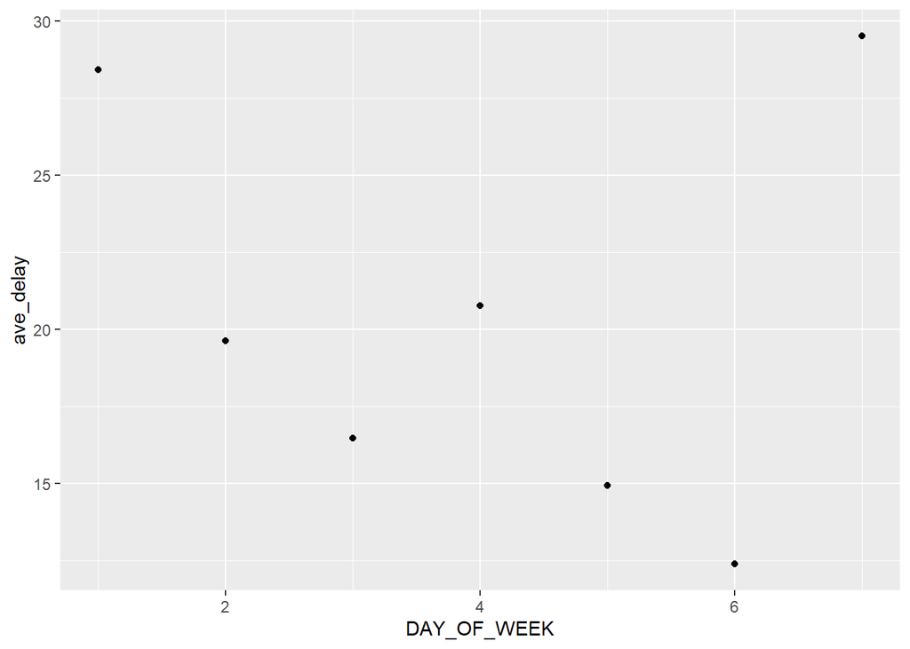

```r
data1 <- flights %>%
  group_by(DAY_OF_WEEK) %>%
  summarise(ave_delay = mean(DEPARTURE_DELAY, na.rm = TRUE),
            n = n())
ggplot(data = data1) +
  geom_point(mapping = aes(x = DAY_OF_WEEK, y = ave_delay))
```

- **(b)** Airlines are grouped into different terminals. There is a belief that certain terminals have better taxing out time. How does **median** taxi out time differ among diferrent airlines?

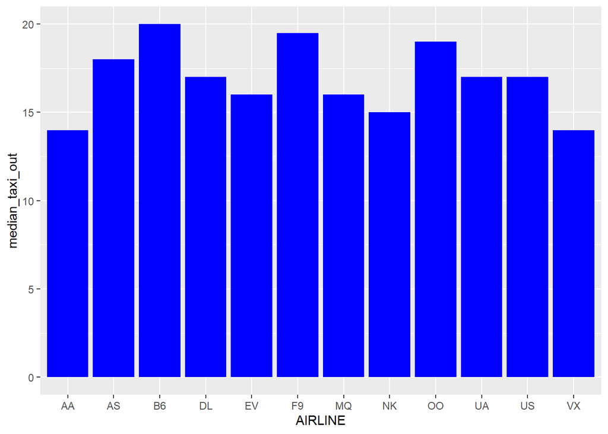

```r
data2 <- flights %>%
  group_by(AIRLINE) %>%
  summarise(median_taxi_out = median(TAXI_OUT, na.rm = TRUE),
            n = n())
ggplot(data = data2, aes(x = AIRLINE, y = median_taxi_out)) +
  geom_bar(stat = "identity", fill= "blue")
```